# CONCEPTION - Demonstration project 4: Migraine

Pregnancy algorithm and application of related exclusion criteria

General information:

- **Script directory:** /Users/vhoxhaj/Desktop/DP4_Migraine_GitHub/Demonstration project/DP4_Migraine
- **Date/time:** 2023-04-11 10:55:22
- **DAP:** ARS
- **Data source:** ARS

| DAP | Script | Start_date | End_date | Time_elaspsed |
| --- | --- | --- | --- | --- |
| ARS | Step_00_create_clean_pregnancy_D3.R | 2023-04-11 | 2023-04-11 | 0.1 secs |

Minimum and maximum dates of start date of pregnancy records for all projects by DAP

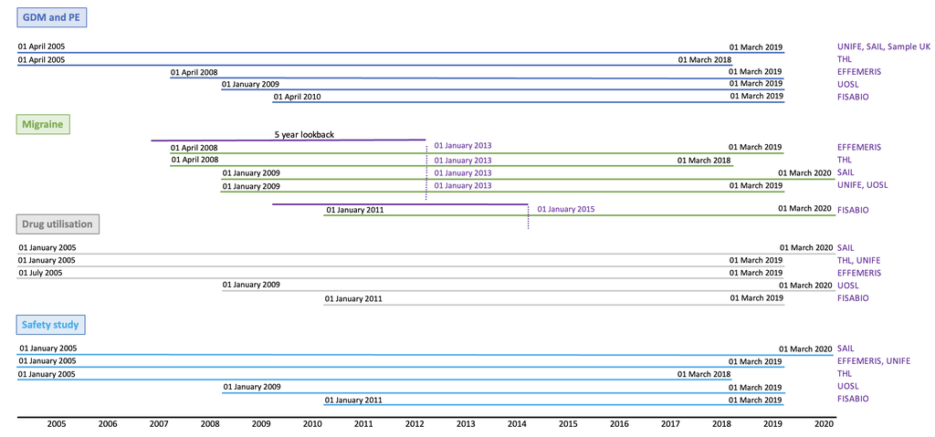

pregnancy dates

## 1. Application of pregnancy algorithm and records quality

Step 1: application of the Pregnancy algorithm(developed by ARS Toscana team).  
Step 2: keep only pregnancy records with quality==“green”.

Removed records with quality other than green

|  | Indicator | Quality | removed_records | percentage |
| --- | --- | --- | --- | --- |
| 1 | Pregnancy records | yellow | 0 | 0 |
| 2 | Pregnancy records | blue | 0 | 0 |
| 3 | Pregnancy records | red | 0 | 0 |

## 2. Application of the same exclusion criteria to pregnancy D3

Below all indicators and number of removed records is explained.

|  | Indicator | Count |
| --- | --- | --- |
| 1 | 1.0. Number of original records from the pregnancy algorithm | 256 |
| 2 | 1.1. Number of records with quality other than green | 0 |
| 3 | 1.2. Records with sex other than female | 39 |
| 4 | 1.3. Records with missing start or end date of pregnancy or both | 0 |
| 5 | 1.4. Records with missing person id | 0 |
| 6 | 1.5. Records with missing pregnancy id | 0 |
| 7 | 1.6. Records where gestational age is longer than 43 weeks(301 days) | 0 |
| 8 | 1.7. Records left after exclusions | 217 |

## 3. Application of the specific exclusion criteria to pregnancy D3 for GDM and PE algorithm

|  | Indicator | GDM_and_PE |
| --- | --- | --- |
| 1 | 1.0. Records with start date before: 2009-01-01 | 67 |
| 2 | 1.1. Records with end date after: 2019-03-01 | 7 |
| 3 | 1.2. Records with GA&lt;20 weeks(140 days) | 35 |
| 4 | 1.3. Records left after removing all issues above | 108 |

## 4. Application of the specific exclusion criteria to pregnancy D3 for Migraine algorithm

|  | Indicator | Migraine |
| --- | --- | --- |
| 1 | 1.0. Records with start date before: 2009-01-01 | 67 |
| 2 | 1.1. Records with end date after: 2019-03-01 | 7 |
| 3 | 1.2. Records with pregnancy outcome other than LB/SB | 2 |
| 4 | 1.3. Records left after removing all issues above | 141 |

## 5. Application of the specific exclusion criteria to pregnancy D3 for the Drug utilization study

[output not shown]

## 6. Application of the specific exclusion criteria to pregnancy D3 for the Safety study

|  | Indicator | Safety |
| --- | --- | --- |
| 1 | 1.0. Records with start date before: 2009-01-01 | 67 |
| 2 | 1.1. Records with end date after: 2019-03-01 | 7 |
| 3 | 1.2. Records with pregnancy outcome other than LB/SB | 2 |
| 4 | 1.3. Records left after removing all issues above | 141 |

## 7. Summary of included records for all projects by year of start pregnancy date

|  | year | GDM_and_PE | Migraine | Drug_utilisation | Safety |
| --- | --- | --- | --- | --- | --- |
| 1 | 2009 | 7 | 10 | 10 | 10 |
| 2 | 2010 | 9 | 18 | 18 | 18 |
| 3 | 2011 | 5 | 7 | 7 | 7 |
| 4 | 2012 | 16 | 19 | 19 | 19 |
| 5 | 2013 | 8 | 11 | 11 | 11 |
| 6 | 2014 | 12 | 12 | 12 | 12 |
| 7 | 2015 | 11 | 17 | 17 | 17 |
| 8 | 2016 | 11 | 13 | 13 | 13 |
| 9 | 2017 | 18 | 19 | 19 | 19 |
| 10 | 2018 | 10 | 14 | 14 | 14 |

[output cut: 1 more lines]

Author: Vjola Hoxhaj Drs.  
email: v.hoxhaj@umcutrecht.nl  
Organisation: UMC Utrecht, Utrecht, The Netherlands